# STATS506 Problem Set #03

Author

Fan Zhang

Published

October 6, 2023

GitHub Repository: https://github.com/cajole-fff/UMich-STATS506-FanZhang/

## Problem 1 - Vision

This problem will require you to do things in Stata we have not covered. Use the Stata help, or online resources, to figure out the appropriate command(s). Use the citation as necessary.

**a. Download the file VIX_D from this location, and determine how to read it into Stata. Then download the file DEMO_D from this location. Note that each page contains a link to a documentation file for that data set. Merge the two files to create a single Stata dataset, using the SEQN variable for merging. Keep only records which matched. Print our your total sample size, showing that it is now 6,980.**

According to the [documentation](https://www.stata.com/manuals13/dimportsasxport.pdf), I can use `import sasxport` to read SAS XPORT files into Stata.

```stata
. import sasxport5 VIX_D.XPT, clear
```

According to the [documentation](https://www.stata.com/manuals/dmerge.pdf), I can use `merge` to merge two datasets.

```stata
. import sasxport5 VIX_D.XPT, clear

. save VIX_D.dta, replace
file VIX_D.dta saved

. import sasxport5 DEMO_D.XPT, clear

. save DEMO_D.dta, replace
file DEMO_D.dta saved

. use VIX_D.dta, clear

. merge 1:1 seqn using "DEMO_D.dta", keep(match)

    Result                      Number of obs
    -----------------------------------------
    Not matched                             0
    Matched                             6,980  (_merge==3)
    -----------------------------------------
```

**b. Without fitting any models, estimate the proportion of responedents within each 10-year age bracket (e.g. 0-9, 10-19, 20-29, etc) who wear glasses/contact lenses for distance vision. Produce a nice table with the results.**

According to the [documentation](https://www.stata.com/manuals13/rtabulatetwoway.pdf), I can use `tabulate` with option `col` to produce a two-way table.

```stata
. gen age_group = floor(ridageyr/10)*10

. tabulate viq220 age_group, col

+-------------------+
| Key               |
|-------------------|
|     frequency     |
| column percentage |
+-------------------+

Glasses/co |
     ntact |
    lenses |
  worn for |                                        age_group
  distance |        10         20         30         40         50         60         70         80 |     Total
-----------+----------------------------------------------------------------------------------------+----------
         1 |       670        306        269        286        335        392        299        208 |     2,765
           |     32.09      32.59      35.87      37.00      55.01      62.22      66.89      66.88 |     42.23
-----------+----------------------------------------------------------------------------------------+----------
         2 |     1,418        631        481        487        274        238        148        103 |     3,780
           |     67.91      67.20      64.13      63.00      44.99      37.78      33.11      33.12 |     57.74
-----------+----------------------------------------------------------------------------------------+----------
         9 |         0          2          0          0          0          0          0          0 |         2
           |      0.00       0.21       0.00       0.00       0.00       0.00       0.00       0.00 |      0.03
-----------+----------------------------------------------------------------------------------------+----------
     Total |     2,088        939        750        773        609        630        447        311 |     6,547
           |    100.00     100.00     100.00     100.00     100.00     100.00     100.00     100.00 |    100.00
```

**c. Fit three logistic regression models predicting whether a respondent wears glasses/contact lenses for distance vision. Produce a table presenting the estimated odds ratios for the coefficients in each model, along with the sample size for the model, the pseudo $R^2$, and AIC values.**

Predictors:

1. Predictor: age

```stata
// Create a new variable viq220_reg for logistic regression
// If viq220 == 1, viq220_reg == 1; otherwise, viq220_reg == 0

. gen viq220_reg = (viq220 == 1)

. logit viq220_reg ridageyr

Iteration 0:  Log likelihood = -4686.4561
Iteration 1:  Log likelihood = -4482.1322
Iteration 2:  Log likelihood = -4481.7871
Iteration 3:  Log likelihood = -4481.7871

Logistic regression                                     Number of obs =  6,980
                                                        LR chi2(1)    = 409.34
                                                        Prob > chi2   = 0.0000
Log likelihood = -4481.7871                             Pseudo R2     = 0.0437

------------------------------------------------------------------------------
  viq220_reg | Coefficient  Std. err.      z    P>|z|     [95% conf. interval]
-------------+----------------------------------------------------------------
    ridageyr |   .0228955    .001157    19.79   0.000     .0206278    .0251631
       _cons |   -1.30923   .0521054   -25.13   0.000    -1.411355   -1.207106
------------------------------------------------------------------------------

// Produce a table presenting the estimated odds ratios for the coefficients in each model,
// along with the sample size for the model, the pseudo  𝑅2 , and AIC values.
. esttab, cells(b(star fmt(3)) se(par fmt(3))) noobs


. esttab, eform se(%9.2f) star(* 0.1 ** 0.05 *** 0.01) stats(N r2_p aic) title("Logistic Regression Models for Glasses/Contact Lenses")

Logistic Regression Models for Glasses/Contact Lenses
----------------------------
                      (1)
               viq220_reg
----------------------------
viq220_reg
ridageyr            1.023***
                   (0.00)
----------------------------
N                    6980
r2_p               0.0437
aic                8967.6
----------------------------
Exponentiated coefficients; Standard errors in parentheses
* p<0.1, ** p<0.05, *** p<0.01
```

2. Predictors: age, race, gender

```stata
. logit viq220_reg ridageyr ridreth1 riagendr

Iteration 0:  Log likelihood = -4686.4561
Iteration 1:  Log likelihood = -4432.2417
Iteration 2:  Log likelihood = -4431.2822
Iteration 3:  Log likelihood = -4431.2821

Logistic regression                                     Number of obs =  6,980
                                                        LR chi2(3)    = 510.35
                                                        Prob > chi2   = 0.0000
Log likelihood = -4431.2821                             Pseudo R2     = 0.0544

------------------------------------------------------------------------------
  viq220_reg | Coefficient  Std. err.      z    P>|z|     [95% conf. interval]
-------------+----------------------------------------------------------------
    ridageyr |   .0230428   .0011715    19.67   0.000     .0207468    .0253388
    ridreth1 |   .1117481   .0218705     5.11   0.000     .0688826    .1546135
    riagendr |   .4392872   .0511169     8.59   0.000     .3390998    .5394745
       _cons |  -2.305327   .1152477   -20.00   0.000    -2.531209   -2.079446
------------------------------------------------------------------------------

. esttab, eform se(%9.2f) star(* 0.1 ** 0.05 *** 0.01) stats(N r2_p aic) title("Logistic Regression Models for Glasses/Contact Lenses")

Logistic Regression Models for Glasses/Contact Lenses
----------------------------
                      (1)
               viq220_reg
----------------------------
viq220_reg
ridageyr            1.023***
                   (0.00)

ridreth1            1.118***
                   (0.02)

riagendr            1.552***
                   (0.08)
----------------------------
N                    6980
r2_p               0.0544
aic                8870.6
----------------------------
Exponentiated coefficients; Standard errors in parentheses
* p<0.1, ** p<0.05, *** p<0.01
```

3. Predictors: age, race, gender, Poverty Income ratio

```stata
. logit viq220_reg ridageyr ridreth1 riagendr indfmpir

Iteration 0:  Log likelihood = -4467.3703
Iteration 1:  Log likelihood = -4192.5804
Iteration 2:  Log likelihood = -4191.1253
Iteration 3:  Log likelihood = -4191.1249

Logistic regression                                     Number of obs =  6,638
                                                        LR chi2(4)    = 552.49
                                                        Prob > chi2   = 0.0000
Log likelihood = -4191.1249                             Pseudo R2     = 0.0618

------------------------------------------------------------------------------
  viq220_reg | Coefficient  Std. err.      z    P>|z|     [95% conf. interval]
-------------+----------------------------------------------------------------
    ridageyr |   .0219737   .0012135    18.11   0.000     .0195953    .0243521
    ridreth1 |   .0785997   .0229914     3.42   0.001     .0335374     .123662
    riagendr |   .4610131   .0526539     8.76   0.000     .3578133    .5642129
    indfmpir |    .150954   .0165745     9.11   0.000     .1184686    .1834394
       _cons |  -2.570646   .1246284   -20.63   0.000    -2.814913   -2.326379
------------------------------------------------------------------------------

. esttab, eform se(%9.2f) star(* 0.1 ** 0.05 *** 0.01) stats(N r2_p aic) title("Logistic Regression Models for Glasses/Contact Lenses")

Logistic Regression Models for Glasses/Contact Lenses
----------------------------
                      (1)
               viq220_reg
----------------------------
viq220_reg
ridageyr            1.022***
                   (0.00)

ridreth1            1.082***
                   (0.02)

riagendr            1.586***
                   (0.08)

indfmpir            1.163***
                   (0.02)
----------------------------
N                    6638
r2_p               0.0618
aic                8392.2
----------------------------
Exponentiated coefficients; Standard errors in parentheses
* p<0.1, ** p<0.05, *** p<0.01
```

**d. From the third model from the previous part, discuss whether the *odds* of men and women being wears of glasses/contact lenses for distance vision differs. Test whether the *proportion* of wearers of glasses/contact lenses for distance vision differs between men and women. Include the results of the test and its interpretation.**

According to the summary of the third model, the odds of `riagendr` is $1.586$. Therefore, the odds of men and women being wears of glasses contact lenses for distance vision differs. Let’s do a test using Stata:

```stata
. test riagendr

 ( 1)  [viq220_reg]riagendr = 0

           chi2(  1) =   76.66
         Prob > chi2 =    0.0000
```

According to the test result, since `Prob > chi2 = 0.0000`, the variable `riagendr` is a significant predictor of the outcome variable, which means the odds of men and women being wears of glasses/contact lenses for distance vision differs.

## Problem 2 - Sakila

Load the “sakila” database discussed in class into SQLite. It can be downloaded from https://github.com/bradleygrant/sakila-sqlite3.

**a. Aside from English, what language is most common for films? Answer this with a single SQL query.**

```r
library(DBI)
library(RSQLite)
# Load the "sakila" database discussed in class into SQLite
sakila <- dbConnect(RSQLite::SQLite(), './sakila-sqlite3/sakila_master.db')
dbListTables(sakila)
```

```
 [1] "actor"                  "address"                "category"
 [4] "city"                   "country"                "customer"
 [7] "customer_list"          "film"                   "film_actor"
[10] "film_category"          "film_list"              "film_text"
[13] "inventory"              "language"               "payment"
[16] "rental"                 "sales_by_film_category" "sales_by_store"
[19] "staff"                  "staff_list"             "store"
```

```r
dbGetQuery(sakila, "SELECT * FROM language")
```

```
  language_id     name         last_update
1           1  English 2020-12-23 07:12:12
2           2  Italian 2020-12-23 07:12:12
3           3 Japanese 2020-12-23 07:12:12
4           4 Mandarin 2020-12-23 07:12:12
5           5   French 2020-12-23 07:12:12
6           6   German 2020-12-23 07:12:12
```

```r
# Count the number of films in each language
dbGetQuery(sakila, "SELECT language_id, COUNT(*) AS count FROM film GROUP BY language_id")
```

```
  language_id count
1           1  1000
```

According to the query, only English is used in the films.

**b. What genre of movie is the most common in the data, and how may movies are of this genre?**

```r
# Count the number of films in each genre
dbGetQuery(sakila, "SELECT category_id, COUNT(*) AS count FROM film_category GROUP BY category_id ORDER BY count DESC")
```

```
   category_id count
1           15    74
2            9    73
3            8    69
4            6    68
5            2    66
6            1    64
7           13    63
8            7    62
9           10    61
10          14    61
11           3    60
12           5    58
13           4    57
14          16    57
15          11    56
16          12    51
```

```r
dbGetQuery(sakila, "SELECT * FROM category WHERE category_id = 15")
```

```
  category_id   name         last_update
1          15 Sports 2020-12-23 07:12:31
```

According to the query, the most common genre of movie is `Sports`, and there are 74 movies of this genre.

**c. Identify which country or countries has exactly 9 customers. Answer this with a single SQL query.**

```r
# Find the country with exactly 9 customers
dbGetQuery(sakila, "SELECT country, COUNT(*) AS count FROM customer_list GROUP BY country HAVING count = 9")
```

```
         country count
1 United Kingdom     9
```

According to the query, the country `United Kindom` has exactly 9 customers.

## Problem 3 - US Records

Download the “US - 500 Records” data from https://www.briandunning.com/sample-data/ and import it into R. This is entirely fake data - use it to answer the following questions.

```r
# Load the data
us500 <- read.csv("./us-500/us-500.csv", header = TRUE, sep = ",")
summary(us500)
```

```
  first_name         last_name         company_name         address
 Length:500         Length:500         Length:500         Length:500
 Class :character   Class :character   Class :character   Class :character
 Mode  :character   Mode  :character   Mode  :character   Mode  :character



     city              county             state                zip
 Length:500         Length:500         Length:500         Min.   : 1581
 Class :character   Class :character   Class :character   1st Qu.:16502
 Mode  :character   Mode  :character   Mode  :character   Median :44139
                                                          Mean   :47496
                                                          3rd Qu.:79971
                                                          Max.   :99712
    phone1             phone2             email               web
 Length:500         Length:500         Length:500         Length:500
 Class :character   Class :character   Class :character   Class :character
 Mode  :character   Mode  :character   Mode  :character   Mode  :character
```

```r
head(us500)
```

```
  first_name last_name           company_name              address        city
1      James      Butt      Benton, John B Jr   6649 N Blue Gum St New Orleans
2  Josephine   Darakjy  Chanay, Jeffrey A Esq  4 B Blue Ridge Blvd    Brighton
3        Art    Venere    Chemel, James L Cpa 8 W Cerritos Ave #54  Bridgeport
4      Lenna  Paprocki Feltz Printing Service          639 Main St   Anchorage
5    Donette    Foller    Printing Dimensions         34 Center St    Hamilton
6     Simona   Morasca    Chapman, Ross E Esq         3 Mcauley Dr     Ashland
      county state   zip       phone1       phone2
1    Orleans    LA 70116 504-621-8927 504-845-1427
2 Livingston    MI 48116 810-292-9388 810-374-9840
3 Gloucester    NJ  8014 856-636-8749 856-264-4130
4  Anchorage    AK 99501 907-385-4412 907-921-2010
5     Butler    OH 45011 513-570-1893 513-549-4561
6    Ashland    OH 44805 419-503-2484 419-800-6759
                          email                                 web
1               jbutt@gmail.com        http://www.bentonjohnbjr.com
2 josephine_darakjy@darakjy.org    http://www.chanayjeffreyaesq.com
3                art@venere.org      http://www.chemeljameslcpa.com
4         lpaprocki@hotmail.com http://www.feltzprintingservice.com
5        donette.foller@cox.net   http://www.printingdimensions.com
6            simona@morasca.com      http://www.chapmanrosseesq.com
```

**a. What proportion of email addresses are hosted at a domain with TLD “.net”? (E.g. in the email, “angrycat@greemail.org”, “freemail.org” is the domain, with TLD (top-level domain) “.org”.)**

```r
# FInd the proportion of email addresses with TLD ".net" in the data
library(stringr)
us500$TLD <- str_extract(us500$email, "\\.[a-z]+$")
table(us500$TLD)
```

```
.com .net .org
 366   70   64
```

```r
prop.table(table(us500$TLD))
```

```
 .com  .net  .org
0.732 0.140 0.128
```

According to the calculation, the proportion of email addresses with TLD “.net” is 0.140.

**b. What proportion of email addresses have at least one non alphanumeric character in them?**

```r
# Extract the email name from the email address
us500$emailname <- str_extract(us500$email, "^.+?(?=@)")
# Extract the non alphanumeric character from the email name
us500$non_alphanumeric <- str_extract(us500$emailname, "[^[:alnum:]]")
# Count the proportion of non-NA values in the column
cat("The proportion of email addresses with at least one non alphanumeric character in them is", sum(!is.na(us500$non_alphanumeric))/nrow(us500), ".\n")
```

```
The proportion of email addresses with at least one non alphanumeric character in them is 0.506 .
```

**c. What is the most common area code amonst all phone numbers?**

```r
# Extract the area code from the phone number
us500$area_code1 <- str_extract(us500$phone1, "^\\d{3}")
us500$area_code2 <- str_extract(us500$phone2, "^\\d{3}")

# Calculate the sum of two table and order by count
area_code_count <- table(us500$area_code1) + table(us500$area_code2)
# Find the most common area code
cat("The most common area code amonst all phone numbers is", names(which.max(area_code_count)), ".\n")
```

```
The most common area code amonst all phone numbers is 973 .
```

**d. Produce a histogram of the log of the apartment numbers for all addresses. (You may assume any number after the street is an apartment number.)**

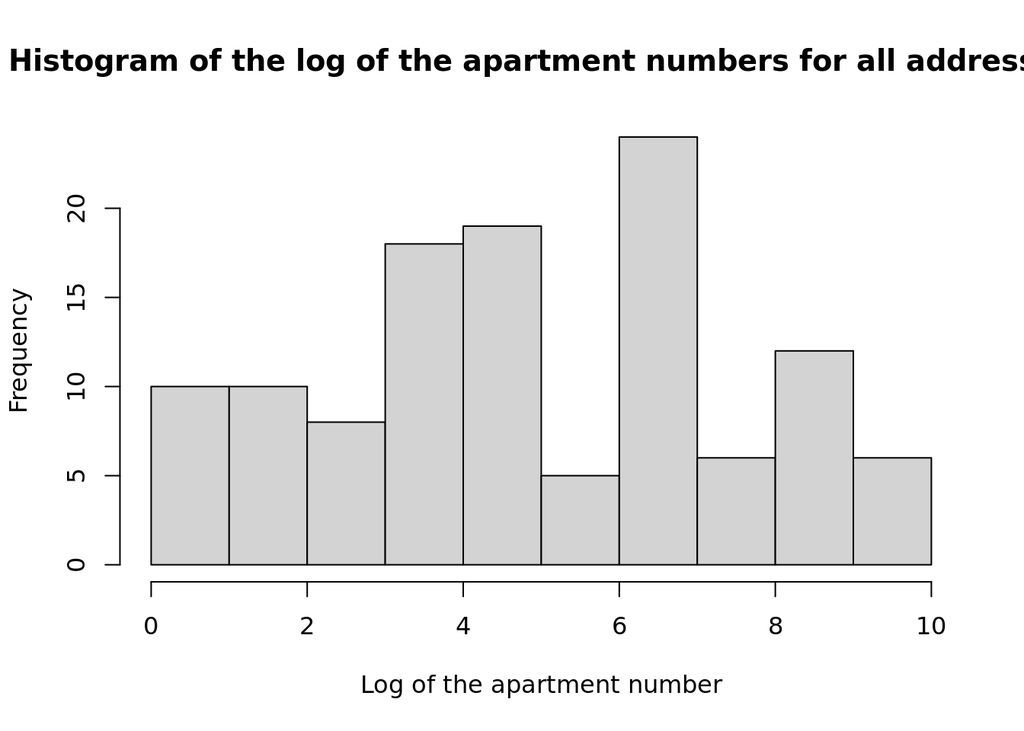

```r
# Extract the apartment number from the address
us500$apartment_number <- as.numeric(str_extract(us500$address, "\\d+$"))
# Calculate the log of the apartment number
us500$log_apartment_number <- log(us500$apartment_number)
# Plot the histogram
hist(us500$log_apartment_number, main = "Histogram of the log of the apartment numbers for all addresses", xlab = "Log of the apartment number")
```

**e. [Benford’s law](https://en.wikipedia.org/wiki/Benford's_law) is an observation about the distribution of the leading digit of real numerical data. Examine whether the apartment numbers appear to follow Benford’s law. Do you think the apartment numbers would pass as real data?**

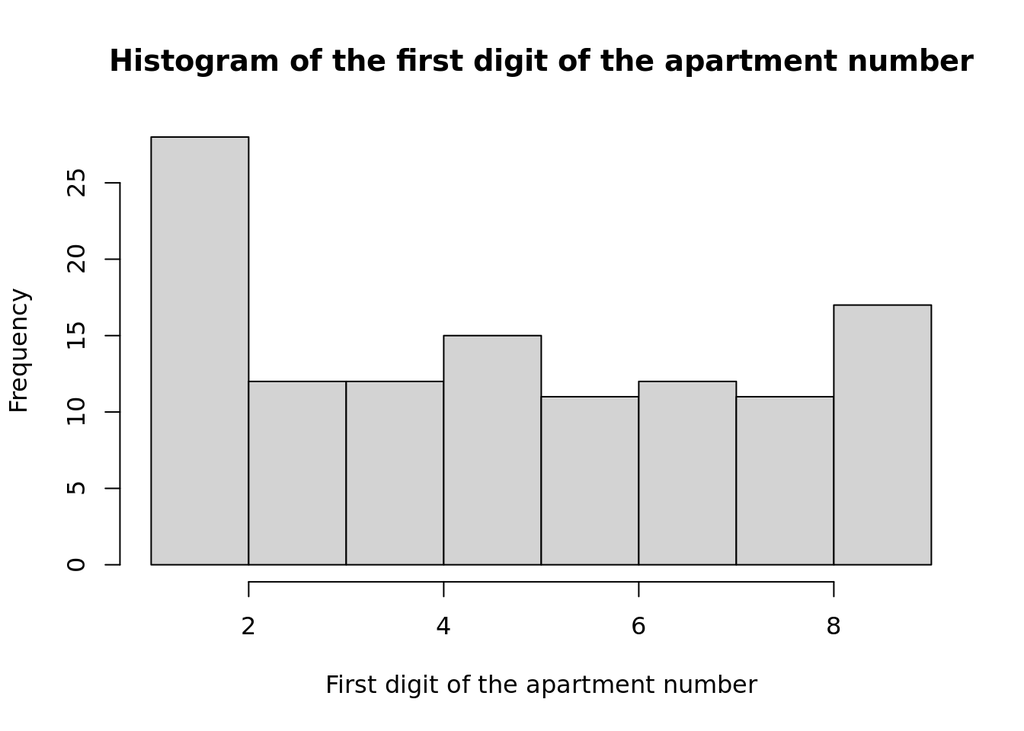

```r
# Extract the first digit of the apartment number
us500$first_digit <- as.numeric(str_extract(us500$apartment_number, "^\\d"))

# Histogram of first digit
hist(us500$first_digit, main = "Histogram of the first digit of the apartment number", xlab = "First digit of the apartment number")
```

```r
# Frequency of each digit
table(us500$first_digit) / sum(table(us500$first_digit))
```

```
         1          2          3          4          5          6          7
0.12711864 0.11016949 0.10169492 0.10169492 0.12711864 0.09322034 0.10169492
         8          9
0.09322034 0.14406780
```

```r
library(benford)
benford(us500$first_digit)
```

```
[1] "Benford's analysis perform better when the analyzed data set ranges for more than\nthree orders of magnitude than when it ranges for just one or two orders of magnitude (Fewster, 2009)."
```

```
[[1]]
            p          RMSD LogLikelihood
  0.006859187   0.075635727 -54.154274865

[[2]]
      [,1] [,2]      [,3]
 [1,]    1   15 35.521539
 [2,]    2   13 20.778769
 [3,]    3   12 14.742771
 [4,]    4   12 11.435382
 [5,]    5   15  9.343387
 [6,]    6   11  7.899721
 [7,]    7   12  6.843050
 [8,]    8   11  6.035998
 [9,]    9   17  5.399384
```

According to the test above, we have a p-value of $0.006859187 < 0.05$, which means the apartment numbers appear *not* to follow Benford’s law. I think the apartment numbers would also not pass as real data.

**f. Repeat your analysis of Benford’s law on the last digit of the street number. (E.g. if your address is “123 Main St #25”, your street number is “123”.)**

```r
# Extract the last digit of the street number
us500$street_number <- as.numeric(str_extract(us500$address, "\\d+$"))
us500$last_digit <- as.numeric(str_extract(us500$street_number, "\\d$"))
benford(us500$last_digit)
```

```
[[1]]
            p          RMSD LogLikelihood
   0.01689982    0.07613409    2.81473700

[[2]]
      [,1] [,2]      [,3]
 [1,]    1   12 32.511240
 [2,]    2   19 19.017856
 [3,]    3   15 13.493384
 [4,]    4    8 10.466281
 [5,]    5    8  8.551575
 [6,]    6   10  7.230253
 [7,]    7   10  6.263130
 [8,]    8    9  5.524472
 [9,]    9   17  4.941809
```

This time we get a p-value $0.01689982 < 0.05$, which means the last digit of the street number also does not follow Benford’s law. It would also not pass as real data.